```python
import pandas as pd
import numpy as np
import pandas_profiling
import seaborn as sns
```

# Game Plan

We will first do some simple EDA and conversion in order for us to have our first submission to Kaggle quickly to establish a baseline.

We will then do further EDA and further model building to produce more enhanced submissions.

# Contents

1. Simple EDA
2. Data Cleaning
3. Linear Models
4. First Submission as Baseline
5. Further EDA and Transformation
6. Feature Selection and Retraining

# 1. Simple EDA

```python
train = pd.read_csv('/kaggle/input/train.csv')
test = pd.read_csv('/kaggle/input/test.csv')
```

```python
train
```

|  | Id | MSSubClass | MSZoning | LotFrontage | LotArea | Street | Alley | LotShape | LandContour | Utilities | ... | PoolArea | PoolQC | Fence | MiscFeature | MiscVal | MoSold | YrSold | SaleType | SaleCondition | SalePrice |
| --- | --- | --- | --- | --- | --- | --- | --- | --- | --- | --- | --- | --- | --- | --- | --- | --- | --- | --- | --- | --- | --- |
| 0 | 1 | 60 | RL | 65.0 | 8450 | Pave | NaN | Reg | Lvl | AllPub | ... | 0 | NaN | NaN | NaN | 0 | 2 | 2008 | WD | Normal | 208500 |
| 1 | 2 | 20 | RL | 80.0 | 9600 | Pave | NaN | Reg | Lvl | AllPub | ... | 0 | NaN | NaN | NaN | 0 | 5 | 2007 | WD | Normal | 181500 |
| 2 | 3 | 60 | RL | 68.0 | 11250 | Pave | NaN | IR1 | Lvl | AllPub | ... | 0 | NaN | NaN | NaN | 0 | 9 | 2008 | WD | Normal | 223500 |
| 3 | 4 | 70 | RL | 60.0 | 9550 | Pave | NaN | IR1 | Lvl | AllPub | ... | 0 | NaN | NaN | NaN | 0 | 2 | 2006 | WD | Abnorml | 140000 |
| 4 | 5 | 60 | RL | 84.0 | 14260 | Pave | NaN | IR1 | Lvl | AllPub | ... | 0 | NaN | NaN | NaN | 0 | 12 | 2008 | WD | Normal | 250000 |
| ... | ... | ... | ... | ... | ... | ... | ... | ... | ... | ... | ... | ... | ... | ... | ... | ... | ... | ... | ... | ... | ... |
| 1455 | 1456 | 60 | RL | 62.0 | 7917 | Pave | NaN | Reg | Lvl | AllPub | ... | 0 | NaN | NaN | NaN | 0 | 8 | 2007 | WD | Normal | 175000 |
| 1456 | 1457 | 20 | RL | 85.0 | 13175 | Pave | NaN | Reg | Lvl | AllPub | ... | 0 | NaN | MnPrv | NaN | 0 | 2 | 2010 | WD | Normal | 210000 |
| 1457 | 1458 | 70 | RL | 66.0 | 9042 | Pave | NaN | Reg | Lvl | AllPub | ... | 0 | NaN | GdPrv | Shed | 2500 | 5 | 2010 | WD | Normal | 266500 |
| 1458 | 1459 | 20 | RL | 68.0 | 9717 | Pave | NaN | Reg | Lvl | AllPub | ... | 0 | NaN | NaN | NaN | 0 | 4 | 2010 | WD | Normal | 142125 |
| 1459 | 1460 | 20 | RL | 75.0 | 9937 | Pave | NaN | Reg | Lvl | AllPub | ... | 0 | NaN | NaN | NaN | 0 | 6 | 2008 | WD | Normal | 147500 |

1460 rows × 81 columns

```python
train.info()
```

```
<class 'pandas.core.frame.DataFrame'>

RangeIndex: 1460 entries, 0 to 1459

Data columns (total 81 columns):

 #   Column         Non-Null Count  Dtype

---  ------         --------------  -----

 0   Id             1460 non-null   int64

 1   MSSubClass     1460 non-null   int64

 2   MSZoning       1460 non-null   object

 3   LotFrontage    1201 non-null   float64

 4   LotArea        1460 non-null   int64

 5   Street         1460 non-null   object

 6   Alley          91 non-null     object

 7   LotShape       1460 non-null   object

 8   LandContour    1460 non-null   object

 9   Utilities      1460 non-null   object

 10  LotConfig      1460 non-null   object

 11  LandSlope      1460 non-null   object

 12  Neighborhood   1460 non-null   object

 13  Condition1     1460 non-null   object

 14  Condition2     1460 non-null   object

```

[output cut: 120 more lines]

```
 75  MiscVal        1460 non-null   int64

 76  MoSold         1460 non-null   int64

 77  YrSold         1460 non-null   int64

 78  SaleType       1460 non-null   object

 79  SaleCondition  1460 non-null   object

 80  SalePrice      1460 non-null   int64

dtypes: float64(3), int64(35), object(43)

memory usage: 924.0+ KB
```

```python
train.describe().T
```

|  | count | mean | std | min | 25% | 50% | 75% | max |
| --- | --- | --- | --- | --- | --- | --- | --- | --- |
| Id | 1460.0 | 730.500000 | 421.610009 | 1.0 | 365.75 | 730.5 | 1095.25 | 1460.0 |
| MSSubClass | 1460.0 | 56.897260 | 42.300571 | 20.0 | 20.00 | 50.0 | 70.00 | 190.0 |
| LotFrontage | 1201.0 | 70.049958 | 24.284752 | 21.0 | 59.00 | 69.0 | 80.00 | 313.0 |
| LotArea | 1460.0 | 10516.828082 | 9981.264932 | 1300.0 | 7553.50 | 9478.5 | 11601.50 | 215245.0 |
| OverallQual | 1460.0 | 6.099315 | 1.382997 | 1.0 | 5.00 | 6.0 | 7.00 | 10.0 |
| OverallCond | 1460.0 | 5.575342 | 1.112799 | 1.0 | 5.00 | 5.0 | 6.00 | 9.0 |
| YearBuilt | 1460.0 | 1971.267808 | 30.202904 | 1872.0 | 1954.00 | 1973.0 | 2000.00 | 2010.0 |
| YearRemodAdd | 1460.0 | 1984.865753 | 20.645407 | 1950.0 | 1967.00 | 1994.0 | 2004.00 | 2010.0 |
| MasVnrArea | 1452.0 | 103.685262 | 181.066207 | 0.0 | 0.00 | 0.0 | 166.00 | 1600.0 |
| BsmtFinSF1 | 1460.0 | 443.639726 | 456.098091 | 0.0 | 0.00 | 383.5 | 712.25 | 5644.0 |
| BsmtFinSF2 | 1460.0 | 46.549315 | 161.319273 | 0.0 | 0.00 | 0.0 | 0.00 | 1474.0 |
| BsmtUnfSF | 1460.0 | 567.240411 | 441.866955 | 0.0 | 223.00 | 477.5 | 808.00 | 2336.0 |
| TotalBsmtSF | 1460.0 | 1057.429452 | 438.705324 | 0.0 | 795.75 | 991.5 | 1298.25 | 6110.0 |
| 1stFlrSF | 1460.0 | 1162.626712 | 386.587738 | 334.0 | 882.00 | 1087.0 | 1391.25 | 4692.0 |
| 2ndFlrSF | 1460.0 | 346.992466 | 436.528436 | 0.0 | 0.00 | 0.0 | 728.00 | 2065.0 |
| LowQualFinSF | 1460.0 | 5.844521 | 48.623081 | 0.0 | 0.00 | 0.0 | 0.00 | 572.0 |
| GrLivArea | 1460.0 | 1515.463699 | 525.480383 | 334.0 | 1129.50 | 1464.0 | 1776.75 | 5642.0 |
| BsmtFullBath | 1460.0 | 0.425342 | 0.518911 | 0.0 | 0.00 | 0.0 | 1.00 | 3.0 |
| BsmtHalfBath | 1460.0 | 0.057534 | 0.238753 | 0.0 | 0.00 | 0.0 | 0.00 | 2.0 |
| FullBath | 1460.0 | 1.565068 | 0.550916 | 0.0 | 1.00 | 2.0 | 2.00 | 3.0 |
| HalfBath | 1460.0 | 0.382877 | 0.502885 | 0.0 | 0.00 | 0.0 | 1.00 | 2.0 |
| BedroomAbvGr | 1460.0 | 2.866438 | 0.815778 | 0.0 | 2.00 | 3.0 | 3.00 | 8.0 |
| KitchenAbvGr | 1460.0 | 1.046575 | 0.220338 | 0.0 | 1.00 | 1.0 | 1.00 | 3.0 |
| TotRmsAbvGrd | 1460.0 | 6.517808 | 1.625393 | 2.0 | 5.00 | 6.0 | 7.00 | 14.0 |
| Fireplaces | 1460.0 | 0.613014 | 0.644666 | 0.0 | 0.00 | 1.0 | 1.00 | 3.0 |
| GarageYrBlt | 1379.0 | 1978.506164 | 24.689725 | 1900.0 | 1961.00 | 1980.0 | 2002.00 | 2010.0 |
| GarageCars | 1460.0 | 1.767123 | 0.747315 | 0.0 | 1.00 | 2.0 | 2.00 | 4.0 |
| GarageArea | 1460.0 | 472.980137 | 213.804841 | 0.0 | 334.50 | 480.0 | 576.00 | 1418.0 |
| WoodDeckSF | 1460.0 | 94.244521 | 125.338794 | 0.0 | 0.00 | 0.0 | 168.00 | 857.0 |
| OpenPorchSF | 1460.0 | 46.660274 | 66.256028 | 0.0 | 0.00 | 25.0 | 68.00 | 547.0 |
| EnclosedPorch | 1460.0 | 21.954110 | 61.119149 | 0.0 | 0.00 | 0.0 | 0.00 | 552.0 |
| 3SsnPorch | 1460.0 | 3.409589 | 29.317331 | 0.0 | 0.00 | 0.0 | 0.00 | 508.0 |
| ScreenPorch | 1460.0 | 15.060959 | 55.757415 | 0.0 | 0.00 | 0.0 | 0.00 | 480.0 |
| PoolArea | 1460.0 | 2.758904 | 40.177307 | 0.0 | 0.00 | 0.0 | 0.00 | 738.0 |
| MiscVal | 1460.0 | 43.489041 | 496.123024 | 0.0 | 0.00 | 0.0 | 0.00 | 15500.0 |
| MoSold | 1460.0 | 6.321918 | 2.703626 | 1.0 | 5.00 | 6.0 | 8.00 | 12.0 |
| YrSold | 1460.0 | 2007.815753 | 1.328095 | 2006.0 | 2007.00 | 2008.0 | 2009.00 | 2010.0 |
| SalePrice | 1460.0 | 180921.195890 | 79442.502883 | 34900.0 | 129975.00 | 163000.0 | 214000.00 | 755000.0 |

### Correlation between SalePrice (target) and each feature

```python
train.corr('spearman')['SalePrice'].sort_values()
```

```
EnclosedPorch   -0.218394
KitchenAbvGr    -0.164826
OverallCond     -0.129325
LowQualFinSF    -0.067719
MiscVal         -0.062727
BsmtFinSF2      -0.038806
YrSold          -0.029899
Id              -0.018546
BsmtHalfBath    -0.012189
MSSubClass       0.007192
PoolArea         0.058453
3SsnPorch        0.065440
MoSold           0.069432
ScreenPorch      0.100070
BsmtUnfSF        0.185197
BsmtFullBath     0.225125
BedroomAbvGr     0.234907
2ndFlrSF         0.293598
BsmtFinSF1       0.301871
HalfBath         0.343008
WoodDeckSF       0.353802
LotFrontage      0.409076
MasVnrArea       0.421309
LotArea          0.456461
OpenPorchSF      0.477561
Fireplaces       0.519247
TotRmsAbvGrd     0.532586
YearRemodAdd     0.571159
1stFlrSF         0.575408
GarageYrBlt      0.593788
TotalBsmtSF      0.602725
FullBath         0.635957
GarageArea       0.649379
YearBuilt        0.652682
GarageCars       0.690711
GrLivArea        0.731310
OverallQual      0.809829
SalePrice        1.000000
Name: SalePrice, dtype: float64
```

# 2. Data Cleaning

## Imputing Missing Values

```python
print('Train dataset missing: ')
print('{:<15}- {:>8}'.format('LABEL', 'MISSING'))
for col in train.columns:
    if sum(train[col].isnull()) > 0:
        print('{:<15}: {:>8} {:>8}'.format(col, sum(train[col].isnull()), str(train[col].dtypes)))


print('\nTest dataset missing: ')
print('{:<15}- {:>8}'.format('LABEL', 'MISSING'))
for col in test.columns:
    if sum(test[col].isnull()) > 0:
        print('{:<15}: {:>8} {:>8}'.format(col, sum(test[col].isnull()), str(test[col].dtypes)))
```

```
Train dataset missing:

LABEL          -  MISSING

LotFrontage    :      259  float64

Alley          :     1369   object

MasVnrType     :        8   object

MasVnrArea     :        8  float64

BsmtQual       :       37   object

BsmtCond       :       37   object

BsmtExposure   :       38   object

BsmtFinType1   :       37   object

BsmtFinType2   :       38   object

Electrical     :        1   object

FireplaceQu    :      690   object

GarageType     :       81   object

GarageYrBlt    :       81  float64

GarageFinish   :       81   object

GarageQual     :       81   object

GarageCond     :       81   object

PoolQC         :     1453   object

Fence          :     1179   object

```

[output cut: 58 more lines]

```
GarageCars     :        1  float64

GarageArea     :        1  float64

GarageQual     :       78   object

GarageCond     :       78   object

PoolQC         :     1456   object

Fence          :     1169   object

MiscFeature    :     1408   object

SaleType       :        1   object
```

```python
train['Utilities'].value_counts()
```

```
AllPub    1459
NoSeWa       1
Name: Utilities, dtype: int64
```

```python
to_drop = ['MasVnrType', 'GarageYrBlt']
fill_zeros = ['LotFrontage', 'MasVnrArea', 'BsmtFinSF1', 'BsmtFinSF2', 'BsmtUnfSF', 'TotalBsmtSF', 'BsmtFullBath',
             'BsmtHalfBath', 'GarageCars', 'GarageArea']
fill_none = ['Alley', 'BsmtQual', 'BsmtCond', 'BsmtExposure', 'BsmtFinType1', 'BsmtFinType2', 'FireplaceQu', 'GarageType',
             'GarageFinish', 'GarageQual', 'GarageCond', 'PoolQC', 'Fence', 'MiscFeature', 'KitchenQual', 'Functional']
fill_mode = ['Electrical', 'MSZoning', 'Utilities', 'Exterior1st', 'Exterior2nd', 'SaleType']
```

```python
train.drop(to_drop, axis=1, inplace=True)
test.drop(to_drop, axis=1, inplace=True)
```

```python
for col in fill_zeros:
    train[col] = train[col].fillna(0)
    test[col] = test[col].fillna(0)

for col in fill_none:
    train[col] = train[col].fillna('None')
    test[col] = test[col].fillna('None')

for col in fill_mode:
    train[col] = train[col].fillna(train[col].mode()[0])
    test[col] = test[col].fillna(train[col].mode()[0])
```

```python
print('Train dataset missing: ')
print('{:<15}- {:>8}'.format('LABEL', 'MISSING'))
for col in train.columns:
    if sum(train[col].isnull()) > 0:
        print('{:<15}: {:>8} {:>8}'.format(col, sum(train[col].isnull()), str(train[col].dtypes)))


print('\nTest dataset missing: ')
print('{:<15}- {:>8}'.format('LABEL', 'MISSING'))
for col in test.columns:
    if sum(test[col].isnull()) > 0:
        print('{:<15}: {:>8} {:>8}'.format(col, sum(test[col].isnull()), str(test[col].dtypes)))
```

```
Train dataset missing:

LABEL          -  MISSING



Test dataset missing:

LABEL          -  MISSING
```

## Column Types Conversion

Converting MSSubClass into categorical variable

```python
train['MSSubClass'] = train['MSSubClass'].apply(str)
test['MSSubClass'] = test['MSSubClass'].apply(str)

X_train = train.drop(['Id', 'SalePrice'], axis=1)
Y_train = train['SalePrice']
X_test = test.drop(['Id'], axis=1)
```

Numeric variables:

```python
num_var = []

for col in X_train.columns:
    if ((str(X_train[col].dtypes) == 'int64' ) or (str(X_train[col].dtypes) == 'float64' )):
        num_var.append(col)

print(num_var)
```

```
['LotFrontage', 'LotArea', 'OverallQual', 'OverallCond', 'YearBuilt', 'YearRemodAdd', 'MasVnrArea', 'BsmtFinSF1', 'BsmtFinSF2', 'BsmtUnfSF', 'TotalBsmtSF', '1stFlrSF', '2ndFlrSF', 'LowQualFinSF', 'GrLivArea', 'BsmtFullBath', 'BsmtHalfBath', 'FullBath', 'HalfBath', 'BedroomAbvGr', 'KitchenAbvGr', 'To…
```

Categorical variables:

```python
cat_var = []

for col in X_train.columns:
    if not ((str(X_train[col].dtypes) == 'int64' ) or (str(X_train[col].dtypes) == 'float64' )):
        cat_var.append(col)

print(cat_var)
```

```
['MSSubClass', 'MSZoning', 'Street', 'Alley', 'LotShape', 'LandContour', 'Utilities', 'LotConfig', 'LandSlope', 'Neighborhood', 'Condition1', 'Condition2', 'BldgType', 'HouseStyle', 'RoofStyle', 'RoofMatl', 'Exterior1st', 'Exterior2nd', 'ExterQual', 'ExterCond', 'Foundation', 'BsmtQual', 'BsmtCond',…
```

# 3. Linear Models

## a. Simplistic linear model with all numeric columns

```python
X_train_num_var = X_train[num_var].copy()
X_test_num_var = X_test[num_var].copy()
```

```python
from sklearn import linear_model
from sklearn.model_selection import cross_val_score

linear_reg = linear_model.LinearRegression()

scores = cross_val_score(linear_reg, X_train_num_var, Y_train, cv=5, scoring='explained_variance')
print("Linear regression: %0.2f explained var score with a standard deviation of %0.2f" % (scores.mean(), scores.std()))
```

```
Linear regression: 0.78 explained var score with a standard deviation of 0.08
```

## b. Advancing the model with log target variable

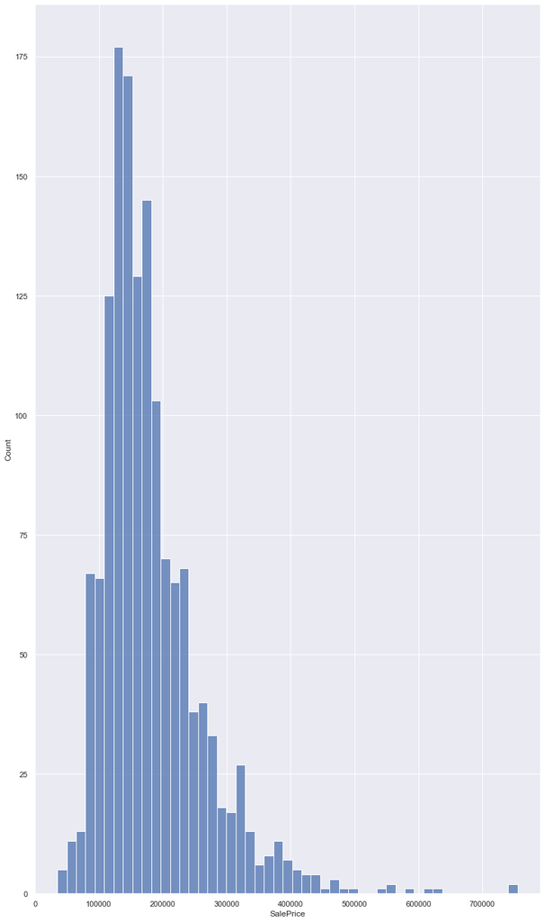

```python
sns.histplot(data=Y_train)
```

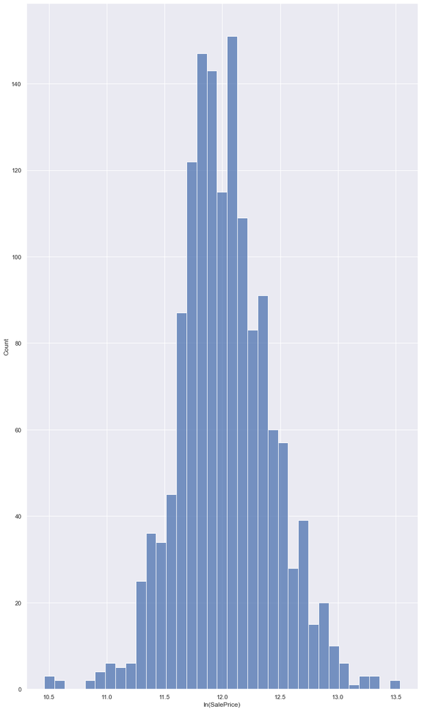

```python
Y_train_log = np.log(Y_train)
Y_train_log.name = 'ln(SalePrice)'

sns.histplot(data=Y_train_log)
```

```python
linear_reg_log_y = linear_model.LinearRegression()

scores = cross_val_score(linear_reg_log_y, X_train_num_var, Y_train_log, cv=5, scoring='explained_variance')
print("Linear regression with log(Y): %0.2f explained var score with a standard deviation of %0.2f" % (scores.mean(), scores.std()))
```

```
Linear regression with log(Y): 0.84 explained var score with a standard deviation of 0.06
```

```python
from sklearn.metrics import make_scorer
from sklearn.metrics import mean_squared_log_error
import math

def rmsle_calc(y_true, y_pred, **kwargs):
    y_pred_exp = list(np.exp(y_pred))
    y_true_exp = list(np.exp(y_true))

    return math.sqrt(mean_squared_log_error(y_pred_exp, y_true_exp)) # somehow mean_squared_log_error() doesn't recognize the "squared=False" argument


exp_rmsle = make_scorer(rmsle_calc, greater_is_better=False)

scores = cross_val_score(linear_reg_log_y, X_train_num_var, Y_train_log, cv=5, scoring=exp_rmsle)
print("Linear regression with log(Y): %0.4f RMSLE score after taking exponential, with a standard deviation of %0.4f" % (scores.mean(), scores.std()))
```

```
Linear regression with log(Y): -0.1558 RMSLE score after taking exponential, with a standard deviation of 0.0269
```

## c. One Hot Encoding with Linear Models and Random Forest

```python
X_train_cat_var = X_train[cat_var].copy()
X_test_cat_var = X_test[cat_var].copy()

for col in X_train_cat_var.columns:
    X_train_cat_var[col] = X_train_cat_var[col] + '_' + col
    X_test_cat_var[col] = X_test_cat_var[col] + '_' + col

X_train_cat_var
```

|  | MSSubClass | MSZoning | Street | Alley | LotShape | LandContour | Utilities | LotConfig | LandSlope | Neighborhood | ... | GarageType | GarageFinish | GarageQual | GarageCond | PavedDrive | PoolQC | Fence | MiscFeature | SaleType | SaleCondition |
| --- | --- | --- | --- | --- | --- | --- | --- | --- | --- | --- | --- | --- | --- | --- | --- | --- | --- | --- | --- | --- | --- |
| 0 | 60_MSSubClass | RL_MSZoning | Pave_Street | None_Alley | Reg_LotShape | Lvl_LandContour | AllPub_Utilities | Inside_LotConfig | Gtl_LandSlope | CollgCr_Neighborhood | ... | Attchd_GarageType | RFn_GarageFinish | TA_GarageQual | TA_GarageCond | Y_PavedDrive | None_PoolQC | None_Fence | None_MiscFeature | WD_SaleType | Normal_SaleCondition |
| 1 | 20_MSSubClass | RL_MSZoning | Pave_Street | None_Alley | Reg_LotShape | Lvl_LandContour | AllPub_Utilities | FR2_LotConfig | Gtl_LandSlope | Veenker_Neighborhood | ... | Attchd_GarageType | RFn_GarageFinish | TA_GarageQual | TA_GarageCond | Y_PavedDrive | None_PoolQC | None_Fence | None_MiscFeature | WD_SaleType | Normal_SaleCondition |
| 2 | 60_MSSubClass | RL_MSZoning | Pave_Street | None_Alley | IR1_LotShape | Lvl_LandContour | AllPub_Utilities | Inside_LotConfig | Gtl_LandSlope | CollgCr_Neighborhood | ... | Attchd_GarageType | RFn_GarageFinish | TA_GarageQual | TA_GarageCond | Y_PavedDrive | None_PoolQC | None_Fence | None_MiscFeature | WD_SaleType | Normal_SaleCondition |
| 3 | 70_MSSubClass | RL_MSZoning | Pave_Street | None_Alley | IR1_LotShape | Lvl_LandContour | AllPub_Utilities | Corner_LotConfig | Gtl_LandSlope | Crawfor_Neighborhood | ... | Detchd_GarageType | Unf_GarageFinish | TA_GarageQual | TA_GarageCond | Y_PavedDrive | None_PoolQC | None_Fence | None_MiscFeature | WD_SaleType | Abnorml_SaleCondition |
| 4 | 60_MSSubClass | RL_MSZoning | Pave_Street | None_Alley | IR1_LotShape | Lvl_LandContour | AllPub_Utilities | FR2_LotConfig | Gtl_LandSlope | NoRidge_Neighborhood | ... | Attchd_GarageType | RFn_GarageFinish | TA_GarageQual | TA_GarageCond | Y_PavedDrive | None_PoolQC | None_Fence | None_MiscFeature | WD_SaleType | Normal_SaleCondition |
| ... | ... | ... | ... | ... | ... | ... | ... | ... | ... | ... | ... | ... | ... | ... | ... | ... | ... | ... | ... | ... | ... |
| 1455 | 60_MSSubClass | RL_MSZoning | Pave_Street | None_Alley | Reg_LotShape | Lvl_LandContour | AllPub_Utilities | Inside_LotConfig | Gtl_LandSlope | Gilbert_Neighborhood | ... | Attchd_GarageType | RFn_GarageFinish | TA_GarageQual | TA_GarageCond | Y_PavedDrive | None_PoolQC | None_Fence | None_MiscFeature | WD_SaleType | Normal_SaleCondition |
| 1456 | 20_MSSubClass | RL_MSZoning | Pave_Street | None_Alley | Reg_LotShape | Lvl_LandContour | AllPub_Utilities | Inside_LotConfig | Gtl_LandSlope | NWAmes_Neighborhood | ... | Attchd_GarageType | Unf_GarageFinish | TA_GarageQual | TA_GarageCond | Y_PavedDrive | None_PoolQC | MnPrv_Fence | None_MiscFeature | WD_SaleType | Normal_SaleCondition |
| 1457 | 70_MSSubClass | RL_MSZoning | Pave_Street | None_Alley | Reg_LotShape | Lvl_LandContour | AllPub_Utilities | Inside_LotConfig | Gtl_LandSlope | Crawfor_Neighborhood | ... | Attchd_GarageType | RFn_GarageFinish | TA_GarageQual | TA_GarageCond | Y_PavedDrive | None_PoolQC | GdPrv_Fence | Shed_MiscFeature | WD_SaleType | Normal_SaleCondition |
| 1458 | 20_MSSubClass | RL_MSZoning | Pave_Street | None_Alley | Reg_LotShape | Lvl_LandContour | AllPub_Utilities | Inside_LotConfig | Gtl_LandSlope | NAmes_Neighborhood | ... | Attchd_GarageType | Unf_GarageFinish | TA_GarageQual | TA_GarageCond | Y_PavedDrive | None_PoolQC | None_Fence | None_MiscFeature | WD_SaleType | Normal_SaleCondition |
| 1459 | 20_MSSubClass | RL_MSZoning | Pave_Street | None_Alley | Reg_LotShape | Lvl_LandContour | AllPub_Utilities | Inside_LotConfig | Gtl_LandSlope | Edwards_Neighborhood | ... | Attchd_GarageType | Fin_GarageFinish | TA_GarageQual | TA_GarageCond | Y_PavedDrive | None_PoolQC | None_Fence | None_MiscFeature | WD_SaleType | Normal_SaleCondition |

1460 rows × 43 columns

```python
from sklearn.preprocessing import OneHotEncoder
# OH_encoder = OneHotEncoder(drop='first', sparse=False).fit(X_train_cat_var)
OH_encoder = OneHotEncoder(handle_unknown='ignore', sparse=False).fit(X_train_cat_var)
OH_encoder.categories_
```

```
[array(['120_MSSubClass', '160_MSSubClass', '180_MSSubClass',
        '190_MSSubClass', '20_MSSubClass', '30_MSSubClass',
        '40_MSSubClass', '45_MSSubClass', '50_MSSubClass', '60_MSSubClass',
        '70_MSSubClass', '75_MSSubClass', '80_MSSubClass', '85_MSSubClass',
        '90_MSSubClass'], dtype=object),
 array(['C (all)_MSZoning', 'FV_MSZoning', 'RH_MSZoning', 'RL_MSZoning',
        'RM_MSZoning'], dtype=object),
 array(['Grvl_Street', 'Pave_Street'], dtype=object),
 array(['Grvl_Alley', 'None_Alley', 'Pave_Alley'], dtype=object),
 array(['IR1_LotShape', 'IR2_LotShape', 'IR3_LotShape', 'Reg_LotShape'],
       dtype=object),
 array(['Bnk_LandContour', 'HLS_LandContour', 'Low_LandContour',
        'Lvl_LandContour'], dtype=object),
 array(['AllPub_Utilities', 'NoSeWa_Utilities'], dtype=object),
 array(['Corner_LotConfig', 'CulDSac_LotConfig', 'FR2_LotConfig',
        'FR3_LotConfig', 'Inside_LotConfig'], dtype=object),
 array(['Gtl_LandSlope', 'Mod_LandSlope', 'Sev_LandSlope'], dtype=object),
 array(['Blmngtn_Neighborhood', 'Blueste_Neighborhood',
        'BrDale_Neighborhood', 'BrkSide_Neighborhood',
        'ClearCr_Neighborhood', 'CollgCr_Neighborhood',
        'Crawfor_Neighborhood', 'Edwards_Neighborhood',
        'Gilbert_Neighborhood', 'IDOTRR_Neighborhood',
        'MeadowV_Neighborhood', 'Mitchel_Neighborhood',
        'NAmes_Neighborhood', 'NPkVill_Neighborhood',
        'NWAmes_Neighborhood', 'NoRidge_Neighborhood',
        'NridgHt_Neighborhood', 'OldTown_Neighborhood',
        'SWISU_Neighborhood', 'SawyerW_Neighborhood',
        'Sawyer_Neighborhood', 'Somerst_Neighborhood',
        'StoneBr_Neighborhood', 'Timber_Neighborhood',
        'Veenker_Neighborhood'], dtype=object),
 array(['Artery_Condition1', 'Feedr_Condition1', 'Norm_Condition1',
        'PosA_Condition1', 'PosN_Condition1', 'RRAe_Condition1',
        'RRAn_Condition1', 'RRNe_Condition1', 'RRNn_Condition1'],
       dtype=object),
 array(['Artery_Condition2', 'Feedr_Condition2', 'Norm_Condition2',
        'PosA_Condition2', 'PosN_Condition2', 'RRAe_Condition2',
        'RRAn_Condition2', 'RRNn_Condition2'], dtype=object),
 array(['1Fam_BldgType', '2fmCon_BldgType', 'Duplex_BldgType',
        'TwnhsE_BldgType', 'Twnhs_BldgType'], dtype=object),
 array(['1.5Fin_HouseStyle', '1.5Unf_HouseStyle', '1Story_HouseStyle',
```

[output cut: 62 more lines]

```
        'None_GarageQual', 'Po_GarageQual', 'TA_GarageQual'], dtype=object),
 array(['Ex_GarageCond', 'Fa_GarageCond', 'Gd_GarageCond',
        'None_GarageCond', 'Po_GarageCond', 'TA_GarageCond'], dtype=object),
 array(['N_PavedDrive', 'P_PavedDrive', 'Y_PavedDrive'], dtype=object),
 array(['Ex_PoolQC', 'Fa_PoolQC', 'Gd_PoolQC', 'None_PoolQC'], dtype=object),
 array(['GdPrv_Fence', 'GdWo_Fence', 'MnPrv_Fence', 'MnWw_Fence',
        'None_Fence'], dtype=object),
 array(['Gar2_MiscFeature', 'None_MiscFeature', 'Othr_MiscFeature',
        'Shed_MiscFeature', 'TenC_MiscFeature'], dtype=object),
 array(['COD_SaleType', 'CWD_SaleType', 'ConLD_SaleType', 'ConLI_SaleType',
        'ConLw_SaleType', 'Con_SaleType', 'New_SaleType', 'Oth_SaleType',
        'WD_SaleType'], dtype=object),
 array(['Abnorml_SaleCondition', 'AdjLand_SaleCondition',
        'Alloca_SaleCondition', 'Family_SaleCondition',
        'Normal_SaleCondition', 'Partial_SaleCondition'], dtype=object)]
```

```python
X_train_cat_var_oh_enc = OH_encoder.transform(X_train_cat_var)
X_test_cat_var_oh_enc = OH_encoder.transform(X_test_cat_var)
X_train_cat_var_oh_enc.shape
```

```
(1460, 277)
```

```python
count = 0

for i in OH_encoder.categories_:
    count += len(i)
print(count)
```

```
277
```

```python
X_train_cat_var_oh_enc = pd.DataFrame(X_train_cat_var_oh_enc,
#              columns=[item for sublist in OH_encoder.categories_ for item in sublist[1:] ]) # Note that sublist starting at index 1 so that we are actually droping the first encoded variable for each feature to avoid multicollinearity
             columns=[item for sublist in OH_encoder.categories_ for item in sublist]) # Note that sublist starting at index 1 so that we are actually droping the first encoded variable for each feature to avoid multicollinearity

X_test_cat_var_oh_enc = pd.DataFrame(X_test_cat_var_oh_enc,
#              columns=[item for sublist in OH_encoder.categories_ for item in sublist[1:] ])
             columns=[item for sublist in OH_encoder.categories_ for item in sublist ])

X_train_cat_var_oh_enc
```

|  | 120_MSSubClass | 160_MSSubClass | 180_MSSubClass | 190_MSSubClass | 20_MSSubClass | 30_MSSubClass | 40_MSSubClass | 45_MSSubClass | 50_MSSubClass | 60_MSSubClass | ... | Con_SaleType | New_SaleType | Oth_SaleType | WD_SaleType | Abnorml_SaleCondition | AdjLand_SaleCondition | Alloca_SaleCondition | Family_SaleCondition | Normal_SaleCondition | Partial_SaleCondition |
| --- | --- | --- | --- | --- | --- | --- | --- | --- | --- | --- | --- | --- | --- | --- | --- | --- | --- | --- | --- | --- | --- |
| 0 | 0.0 | 0.0 | 0.0 | 0.0 | 0.0 | 0.0 | 0.0 | 0.0 | 0.0 | 1.0 | ... | 0.0 | 0.0 | 0.0 | 1.0 | 0.0 | 0.0 | 0.0 | 0.0 | 1.0 | 0.0 |
| 1 | 0.0 | 0.0 | 0.0 | 0.0 | 1.0 | 0.0 | 0.0 | 0.0 | 0.0 | 0.0 | ... | 0.0 | 0.0 | 0.0 | 1.0 | 0.0 | 0.0 | 0.0 | 0.0 | 1.0 | 0.0 |
| 2 | 0.0 | 0.0 | 0.0 | 0.0 | 0.0 | 0.0 | 0.0 | 0.0 | 0.0 | 1.0 | ... | 0.0 | 0.0 | 0.0 | 1.0 | 0.0 | 0.0 | 0.0 | 0.0 | 1.0 | 0.0 |
| 3 | 0.0 | 0.0 | 0.0 | 0.0 | 0.0 | 0.0 | 0.0 | 0.0 | 0.0 | 0.0 | ... | 0.0 | 0.0 | 0.0 | 1.0 | 1.0 | 0.0 | 0.0 | 0.0 | 0.0 | 0.0 |
| 4 | 0.0 | 0.0 | 0.0 | 0.0 | 0.0 | 0.0 | 0.0 | 0.0 | 0.0 | 1.0 | ... | 0.0 | 0.0 | 0.0 | 1.0 | 0.0 | 0.0 | 0.0 | 0.0 | 1.0 | 0.0 |
| ... | ... | ... | ... | ... | ... | ... | ... | ... | ... | ... | ... | ... | ... | ... | ... | ... | ... | ... | ... | ... | ... |
| 1455 | 0.0 | 0.0 | 0.0 | 0.0 | 0.0 | 0.0 | 0.0 | 0.0 | 0.0 | 1.0 | ... | 0.0 | 0.0 | 0.0 | 1.0 | 0.0 | 0.0 | 0.0 | 0.0 | 1.0 | 0.0 |
| 1456 | 0.0 | 0.0 | 0.0 | 0.0 | 1.0 | 0.0 | 0.0 | 0.0 | 0.0 | 0.0 | ... | 0.0 | 0.0 | 0.0 | 1.0 | 0.0 | 0.0 | 0.0 | 0.0 | 1.0 | 0.0 |
| 1457 | 0.0 | 0.0 | 0.0 | 0.0 | 0.0 | 0.0 | 0.0 | 0.0 | 0.0 | 0.0 | ... | 0.0 | 0.0 | 0.0 | 1.0 | 0.0 | 0.0 | 0.0 | 0.0 | 1.0 | 0.0 |
| 1458 | 0.0 | 0.0 | 0.0 | 0.0 | 1.0 | 0.0 | 0.0 | 0.0 | 0.0 | 0.0 | ... | 0.0 | 0.0 | 0.0 | 1.0 | 0.0 | 0.0 | 0.0 | 0.0 | 1.0 | 0.0 |
| 1459 | 0.0 | 0.0 | 0.0 | 0.0 | 1.0 | 0.0 | 0.0 | 0.0 | 0.0 | 0.0 | ... | 0.0 | 0.0 | 0.0 | 1.0 | 0.0 | 0.0 | 0.0 | 0.0 | 1.0 | 0.0 |

1460 rows × 277 columns

```python
X_train_combined = pd.merge(X_train_num_var, X_train_cat_var_oh_enc, left_index=True, right_index=True)
X_test_combined = pd.merge(X_test_num_var, X_test_cat_var_oh_enc, left_index=True, right_index=True)
```

CV results with linear regression are actually worse with these one hot encoded variables

```python
linear_reg_combined = linear_model.LinearRegression()
linear_reg_combined.fit(X_train_combined, Y_train_log)


scores = cross_val_score(linear_reg_combined, X_train_combined, Y_train_log, cv=5, scoring=exp_rmsle)
print("Linear regression with encoding and log(Y): %0.4f RMSLE score after taking exponential, with a standard deviation of %0.4f" % (scores.mean(), scores.std()))
```

```
Linear regression with encoding and log(Y): -0.1574 RMSLE score after taking exponential, with a standard deviation of 0.0287
```

```python
from sklearn.linear_model import LassoLarsCV

lasso_reg = LassoLarsCV(max_iter=1000)

scores = cross_val_score(lasso_reg, X_train_num_var, Y_train_log, cv=5, scoring=exp_rmsle)
print("Lasso regression with num vars and log(Y): %0.4f RMSLE score after taking exponential, with a standard deviation of %0.4f" % (scores.mean(), scores.std()))

scores = cross_val_score(lasso_reg, X_train_combined, Y_train_log, cv=5, scoring=exp_rmsle)
print("Lasso regression with all vars and log(Y): %0.4f RMSLE score after taking exponential, with a standard deviation of %0.4f" % (scores.mean(), scores.std()))
```

```
Lasso regression with num vars and log(Y): -0.1555 RMSLE score after taking exponential, with a standard deviation of 0.0257
```

[output not shown]

[output cut: 751 more lines]

[output not shown]

```
Lasso regression with all vars and log(Y): -0.1423 RMSLE score after taking exponential, with a standard deviation of 0.0282
```

Let's also try Random Forest for both numeric variables only and then with all variables

```python
from sklearn.ensemble import RandomForestRegressor

rf_reg = RandomForestRegressor(max_depth=10, random_state=0)

scores = cross_val_score(rf_reg, X_train_num_var, Y_train_log, cv=5, scoring=exp_rmsle)
print("RF regression with num vars and log(Y): %0.4f RMSLE score after taking exponential, with a standard deviation of %0.4f" % (scores.mean(), scores.std()))

scores = cross_val_score(rf_reg, X_train_combined, Y_train_log, cv=5, scoring=exp_rmsle)
print("RF regression with all vars and log(Y): %0.4f RMSLE score after taking exponential, with a standard deviation of %0.4f" % (scores.mean(), scores.std()))
```

```
RF regression with num vars and log(Y): -0.1482 RMSLE score after taking exponential, with a standard deviation of 0.0100

RF regression with all vars and log(Y): -0.1456 RMSLE score after taking exponential, with a standard deviation of 0.0094
```

Not substantially better either. We can submit this to Kaggle as a first submission though.

# 4. First Submission as Baseline

```python
rf_reg.fit(X_train_num_var, Y_train_log)

test_results_log = rf_reg.predict(X_test_num_var)
test_results = np.exp(test_results_log)

first_submission = pd.DataFrame({'Id': test['Id'], 'SalePrice': test_results})
first_submission.to_csv('first_submission.csv', index=False)
```

```python
lasso_reg.fit(X_train_combined, Y_train_log)

test_results_log = lasso_reg.predict(X_test_combined)
test_results = np.exp(test_results_log)

lasso_submission = pd.DataFrame({'Id': test['Id'], 'SalePrice': test_results})
lasso_submission.to_csv('lasso_all_var_submission.csv', index=False)
```

[output not shown]

[output cut: 47 more lines]

[output not shown]

# 5. Further EDA and Transformation

## Numeric variable exploration and transformation

PLOTTING NUMERIC VARIABLES CORRELATION WITH SALEPRICE

```python
train_long_form_num = pd.melt(train.loc[:,num_var+['SalePrice']], id_vars=['SalePrice'], value_vars=num_var)
```

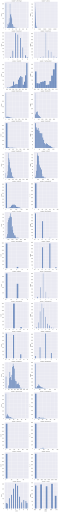

```python
g = sns.FacetGrid(train_long_form_num, col='variable',  col_wrap=2, sharex=False, sharey=False, height=5)
g.map(sns.histplot, "value")
```

To log transform

```python
to_transform = ['LotFrontage', 'LotArea', 'MasVnrArea', 'BsmtFinSF1', 'BsmtUnfSF',
 'TotalBsmtSF', '1stFlrSF', 'GrLivArea', 'GarageArea', 'WoodDeckSF', 'OpenPorchSF']
```

```python
from sklearn.preprocessing import PowerTransformer
pt = PowerTransformer()  #Yeo-Johnson some of the variables

temp_train_transformed = pt.fit_transform(train[to_transform])
temp_test_transformed = pt.transform(test[to_transform])

temp_train_transformed = pd.DataFrame(temp_train_transformed, columns=[i+'_yj' for i in to_transform])
temp_test_transformed = pd.DataFrame(temp_test_transformed, columns=[i+'_yj' for i in to_transform])

train_num_transformed = train.loc[:,num_var+['SalePrice']].drop(to_transform, axis=1)
train_num_transformed = pd.merge(train_num_transformed, temp_train_transformed, left_index=True, right_index=True)

test_num_transformed = test.loc[:,num_var].drop(to_transform, axis=1)
test_num_transformed = pd.merge(test_num_transformed, temp_test_transformed, left_index=True, right_index=True)

# transform SalePrice in train set to log
train_num_transformed['ln(SalePrice)'] = np.log(train_num_transformed['SalePrice'])
train_num_transformed.drop('SalePrice', axis=1, inplace=True)

train_num_transformed
```

|  | OverallQual | OverallCond | YearBuilt | YearRemodAdd | BsmtFinSF2 | 2ndFlrSF | LowQualFinSF | BsmtFullBath | BsmtHalfBath | FullBath | ... | MasVnrArea_yj | BsmtFinSF1_yj | BsmtUnfSF_yj | TotalBsmtSF_yj | 1stFlrSF_yj | GrLivArea_yj | GarageArea_yj | WoodDeckSF_yj | OpenPorchSF_yj | ln(SalePrice) |
| --- | --- | --- | --- | --- | --- | --- | --- | --- | --- | --- | --- | --- | --- | --- | --- | --- | --- | --- | --- | --- | --- |
| 0 | 7 | 5 | 2003 | 2003 | 0 | 854 | 0 | 1 | 0 | 2 | ... | 1.230708 | 0.797537 | -0.887576 | -0.404029 | -0.799624 | 0.528531 | 0.383899 | -0.950337 | 0.841820 | 12.247694 |
| 1 | 6 | 8 | 1976 | 1976 | 0 | 0 | 0 | 0 | 1 | 2 | ... | -0.818452 | 1.011471 | -0.434388 | 0.508177 | 0.429151 | -0.382755 | -0.004602 | 1.213714 | -1.071307 | 12.109011 |
| 2 | 7 | 5 | 2001 | 2002 | 0 | 866 | 0 | 1 | 0 | 2 | ... | 1.193873 | 0.571325 | -0.048083 | -0.253787 | -0.568533 | 0.659112 | 0.641990 | -0.950337 | 0.668453 | 12.317167 |
| 3 | 7 | 5 | 1915 | 1970 | 0 | 756 | 0 | 1 | 0 | 1 | ... | -0.818452 | 0.142272 | 0.183337 | -0.644806 | -0.429428 | 0.540797 | 0.786092 | -0.950337 | 0.584540 | 11.849398 |
| 4 | 8 | 5 | 2000 | 2000 | 0 | 1053 | 0 | 1 | 0 | 2 | ... | 1.333038 | 0.750541 | 0.077485 | 0.254387 | 0.124698 | 1.282894 | 1.583257 | 1.079695 | 0.991895 | 12.429216 |
| ... | ... | ... | ... | ... | ... | ... | ... | ... | ... | ... | ... | ... | ... | ... | ... | ... | ... | ... | ... | ... | ... |
| 1455 | 6 | 5 | 1999 | 2000 | 0 | 694 | 0 | 0 | 0 | 2 | ... | -0.818452 | -1.353159 | 0.909505 | -0.177387 | -0.456061 | 0.415837 | -0.004602 | -0.950337 | 0.645943 | 12.072541 |
| 1456 | 6 | 6 | 1978 | 1988 | 163 | 0 | 0 | 1 | 0 | 2 | ... | 1.130602 | 0.869532 | 0.282161 | 1.092127 | 1.946238 | 1.106859 | 0.173581 | 1.260813 | -1.071307 | 12.254863 |
| 1457 | 7 | 9 | 1941 | 2006 | 0 | 1152 | 0 | 0 | 0 | 2 | ... | -0.818452 | 0.261742 | 0.790731 | 0.269755 | 0.240338 | 1.471180 | -0.987927 | -0.950337 | 0.834100 | 12.493130 |
| 1458 | 5 | 6 | 1950 | 1996 | 1029 | 0 | 0 | 1 | 0 | 1 | ... | -0.818452 | -0.460226 | -2.064084 | 0.106028 | -0.065163 | -0.854788 | -1.048544 | 1.274883 | -1.071307 | 11.864462 |
| 1459 | 5 | 6 | 1965 | 1965 | 290 | 0 | 0 | 1 | 0 | 1 | ... | -0.818452 | 0.901757 | -0.945776 | 0.495315 | 0.414293 | -0.397037 | -0.868284 | 1.475782 | 0.892639 | 11.901583 |

1460 rows × 35 columns

```python
train_num_transformed.corr()['ln(SalePrice)'].sort_values()
```

```
EnclosedPorch    -0.149050
KitchenAbvGr     -0.147548
LowQualFinSF     -0.037963
YrSold           -0.037263
OverallCond      -0.036868
MiscVal          -0.020021
BsmtHalfBath     -0.005149
BsmtFinSF2        0.004832
3SsnPorch         0.054900
MoSold            0.057329
PoolArea          0.069798
ScreenPorch       0.121208
LotFrontage_yj    0.143067
BedroomAbvGr      0.209044
BsmtUnfSF_yj      0.212944
BsmtFullBath      0.236224
BsmtFinSF1_yj     0.249298
HalfBath          0.313982
2ndFlrSF          0.319300
WoodDeckSF_yj     0.339998
MasVnrArea_yj     0.399276
LotArea_yj        0.400276
OpenPorchSF_yj    0.459717
Fireplaces        0.489449
TotRmsAbvGrd      0.534422
YearRemodAdd      0.565608
YearBuilt         0.586570
FullBath          0.594771
1stFlrSF_yj       0.608126
TotalBsmtSF_yj    0.612850
GarageArea_yj     0.647471
GarageCars        0.680625
GrLivArea_yj      0.730240
OverallQual       0.817184
ln(SalePrice)     1.000000
Name: ln(SalePrice), dtype: float64
```

```python
train_long_form_num_transformed = pd.melt(train_num_transformed, id_vars=['ln(SalePrice)'],
                                          value_vars=train_num_transformed.columns.drop('ln(SalePrice)'))
```

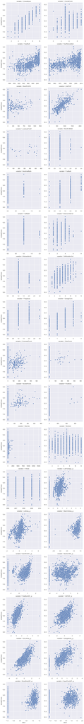

```python
g = sns.FacetGrid(train_long_form_num_transformed, col='variable',  col_wrap=2, sharex=False, sharey=False, height=5)
g.map(sns.scatterplot, 'value', 'ln(SalePrice)')
```

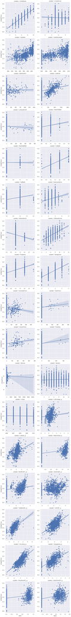

```python
g = sns.FacetGrid(train_long_form_num_transformed, col='variable', col_wrap=2,  sharex=False, sharey=False, height=5)
g.map(sns.regplot, 'value', 'ln(SalePrice)')
```

An interesting point to note is why OverallCond is NEGATIVELY sloped. This would need further digging.

## Categorical variable exploration and transformation

Looking at the below, seems that we will be able to use ordinal encoding for the categorical variables

```python
_ = train.loc[:,cat_var+['SalePrice']]

for col in cat_var:
    print(_.groupby(col).agg(['median', 'count'])['SalePrice'])
    print('\n')
```

```
              median  count

MSSubClass

120         192000.0     87

160         146000.0     63

180          88500.0     10

190         128250.0     30

20          159250.0    536

30           99900.0     69

40          142500.0      4

45          107500.0     12

50          132000.0    144

60          215200.0    299

70          156000.0     60

75          163500.0     16

80          166500.0     58

85          140750.0     20

90          135980.0     52





            median  count

```

[output cut: 837 more lines]

```
                 median  count

SaleCondition

Abnorml        130000.0    101

AdjLand        104000.0      4

Alloca         148145.0     12

Family         140500.0     20

Normal         160000.0   1198

Partial        244600.0    125
```

Taking reference from DOMINIK GAWLIK's notebook from Kaggle and enhancing:

```python
train_long_form_cat = pd.melt(train.loc[:, cat_var+['SalePrice']], id_vars=['SalePrice'], value_vars=cat_var)
train_long_form_cat['ln(SalePrice)'] = np.log(train_long_form_cat['SalePrice'])
train_long_form_cat.drop('SalePrice', axis=1, inplace=True)
```

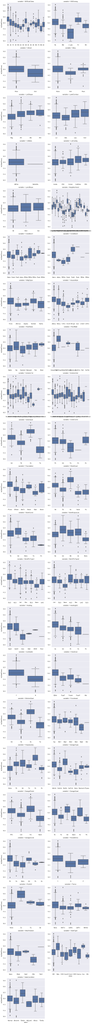

```python
g = sns.FacetGrid(train_long_form_cat, col='variable',  col_wrap=2, sharex=False, sharey=False, height=5)
g.map(sns.boxplot, "value", "ln(SalePrice)")
```

```python
train_with_ord_enc = train[cat_var+['SalePrice']].copy()
test_with_ord_enc = test[cat_var].copy()


def ordinal_encode(df, col):
    idx_names = df.groupby(col).median().sort_values('SalePrice').index
    temp_list = list(zip(idx_names, range(1, 1+len(idx_names))))
    order_dict = {k[0] : k[1] for k in temp_list}

    for key, val in order_dict.items():
        train_with_ord_enc.loc[train_with_ord_enc[col] == key, col+'_E'] = val
        test_with_ord_enc.loc[test_with_ord_enc[col] == key, col+'_E'] = val

    train_with_ord_enc[col+'_E'] = train_with_ord_enc[col+'_E'].astype(int)
    #there is one MSSubClass in the test set but not in the train set, so as a general fix, we fill it with median
    test_with_ord_enc[col+'_E'] = test_with_ord_enc[col+'_E'].fillna(test_with_ord_enc[col+'_E'].median()).astype(int)


for col in cat_var:
    ordinal_encode(train_with_ord_enc, col)

train_with_ord_enc.drop(cat_var+['SalePrice'], axis=1, inplace=True)
test_with_ord_enc.drop(cat_var, axis=1, inplace=True)
train_with_ord_enc
```

|  | MSSubClass_E | MSZoning_E | Street_E | Alley_E | LotShape_E | LandContour_E | Utilities_E | LotConfig_E | LandSlope_E | Neighborhood_E | ... | GarageType_E | GarageFinish_E | GarageQual_E | GarageCond_E | PavedDrive_E | PoolQC_E | Fence_E | MiscFeature_E | SaleType_E | SaleCondition_E |
| --- | --- | --- | --- | --- | --- | --- | --- | --- | --- | --- | --- | --- | --- | --- | --- | --- | --- | --- | --- | --- | --- |
| 0 | 15 | 4 | 2 | 2 | 1 | 2 | 2 | 1 | 1 | 17 | ... | 6 | 3 | 5 | 6 | 3 | 1 | 5 | 3 | 6 | 5 |
| 1 | 11 | 4 | 2 | 2 | 1 | 2 | 2 | 3 | 1 | 20 | ... | 6 | 3 | 5 | 6 | 3 | 1 | 5 | 3 | 6 | 5 |
| 2 | 15 | 4 | 2 | 2 | 2 | 2 | 2 | 1 | 1 | 17 | ... | 6 | 3 | 5 | 6 | 3 | 1 | 5 | 3 | 6 | 5 |
| 3 | 10 | 4 | 2 | 2 | 2 | 2 | 2 | 2 | 1 | 19 | ... | 3 | 2 | 5 | 6 | 3 | 1 | 5 | 3 | 6 | 2 |
| 4 | 15 | 4 | 2 | 2 | 2 | 2 | 2 | 3 | 1 | 24 | ... | 6 | 3 | 5 | 6 | 3 | 1 | 5 | 3 | 6 | 5 |
| ... | ... | ... | ... | ... | ... | ... | ... | ... | ... | ... | ... | ... | ... | ... | ... | ... | ... | ... | ... | ... | ... |
| 1455 | 15 | 4 | 2 | 2 | 1 | 2 | 2 | 1 | 1 | 14 | ... | 6 | 3 | 5 | 6 | 3 | 1 | 5 | 3 | 6 | 5 |
| 1456 | 11 | 4 | 2 | 2 | 1 | 2 | 2 | 1 | 1 | 15 | ... | 6 | 2 | 5 | 6 | 3 | 1 | 2 | 3 | 6 | 5 |
| 1457 | 10 | 4 | 2 | 2 | 1 | 2 | 2 | 1 | 1 | 19 | ... | 6 | 3 | 5 | 6 | 3 | 1 | 4 | 2 | 6 | 5 |
| 1458 | 11 | 4 | 2 | 2 | 1 | 2 | 2 | 1 | 1 | 10 | ... | 6 | 2 | 5 | 6 | 3 | 1 | 5 | 3 | 6 | 5 |
| 1459 | 11 | 4 | 2 | 2 | 1 | 2 | 2 | 1 | 1 | 5 | ... | 6 | 4 | 5 | 6 | 3 | 1 | 5 | 3 | 6 | 5 |

1460 rows × 43 columns

## Combining Transformed Numeric and Categorical Variables

```python
train_transformed = pd.merge(train_with_ord_enc, train_num_transformed, left_index=True, right_index=True)
test_transformed = pd.merge(test_with_ord_enc, test_num_transformed, left_index=True, right_index=True)
```

```python
train_transformed.dtypes
```

```
MSSubClass_E        int32
MSZoning_E          int32
Street_E            int32
Alley_E             int32
LotShape_E          int32
                   ...
GrLivArea_yj      float64
GarageArea_yj     float64
WoodDeckSF_yj     float64
OpenPorchSF_yj    float64
ln(SalePrice)     float64
Length: 78, dtype: object
```

```python
train_transformed
```

|  | MSSubClass_E | MSZoning_E | Street_E | Alley_E | LotShape_E | LandContour_E | Utilities_E | LotConfig_E | LandSlope_E | Neighborhood_E | ... | MasVnrArea_yj | BsmtFinSF1_yj | BsmtUnfSF_yj | TotalBsmtSF_yj | 1stFlrSF_yj | GrLivArea_yj | GarageArea_yj | WoodDeckSF_yj | OpenPorchSF_yj | ln(SalePrice) |
| --- | --- | --- | --- | --- | --- | --- | --- | --- | --- | --- | --- | --- | --- | --- | --- | --- | --- | --- | --- | --- | --- |
| 0 | 15 | 4 | 2 | 2 | 1 | 2 | 2 | 1 | 1 | 17 | ... | 1.230708 | 0.797537 | -0.887576 | -0.404029 | -0.799624 | 0.528531 | 0.383899 | -0.950337 | 0.841820 | 12.247694 |
| 1 | 11 | 4 | 2 | 2 | 1 | 2 | 2 | 3 | 1 | 20 | ... | -0.818452 | 1.011471 | -0.434388 | 0.508177 | 0.429151 | -0.382755 | -0.004602 | 1.213714 | -1.071307 | 12.109011 |
| 2 | 15 | 4 | 2 | 2 | 2 | 2 | 2 | 1 | 1 | 17 | ... | 1.193873 | 0.571325 | -0.048083 | -0.253787 | -0.568533 | 0.659112 | 0.641990 | -0.950337 | 0.668453 | 12.317167 |
| 3 | 10 | 4 | 2 | 2 | 2 | 2 | 2 | 2 | 1 | 19 | ... | -0.818452 | 0.142272 | 0.183337 | -0.644806 | -0.429428 | 0.540797 | 0.786092 | -0.950337 | 0.584540 | 11.849398 |
| 4 | 15 | 4 | 2 | 2 | 2 | 2 | 2 | 3 | 1 | 24 | ... | 1.333038 | 0.750541 | 0.077485 | 0.254387 | 0.124698 | 1.282894 | 1.583257 | 1.079695 | 0.991895 | 12.429216 |
| ... | ... | ... | ... | ... | ... | ... | ... | ... | ... | ... | ... | ... | ... | ... | ... | ... | ... | ... | ... | ... | ... |
| 1455 | 15 | 4 | 2 | 2 | 1 | 2 | 2 | 1 | 1 | 14 | ... | -0.818452 | -1.353159 | 0.909505 | -0.177387 | -0.456061 | 0.415837 | -0.004602 | -0.950337 | 0.645943 | 12.072541 |
| 1456 | 11 | 4 | 2 | 2 | 1 | 2 | 2 | 1 | 1 | 15 | ... | 1.130602 | 0.869532 | 0.282161 | 1.092127 | 1.946238 | 1.106859 | 0.173581 | 1.260813 | -1.071307 | 12.254863 |
| 1457 | 10 | 4 | 2 | 2 | 1 | 2 | 2 | 1 | 1 | 19 | ... | -0.818452 | 0.261742 | 0.790731 | 0.269755 | 0.240338 | 1.471180 | -0.987927 | -0.950337 | 0.834100 | 12.493130 |
| 1458 | 11 | 4 | 2 | 2 | 1 | 2 | 2 | 1 | 1 | 10 | ... | -0.818452 | -0.460226 | -2.064084 | 0.106028 | -0.065163 | -0.854788 | -1.048544 | 1.274883 | -1.071307 | 11.864462 |
| 1459 | 11 | 4 | 2 | 2 | 1 | 2 | 2 | 1 | 1 | 5 | ... | -0.818452 | 0.901757 | -0.945776 | 0.495315 | 0.414293 | -0.397037 | -0.868284 | 1.475782 | 0.892639 | 11.901583 |

1460 rows × 78 columns

```python
SalePrice_corr = pd.DataFrame(train_transformed.corr(method='spearman')['ln(SalePrice)'].sort_values()).reset_index()
```

## Correlation Plot for Both Numeric And Categorical Variables

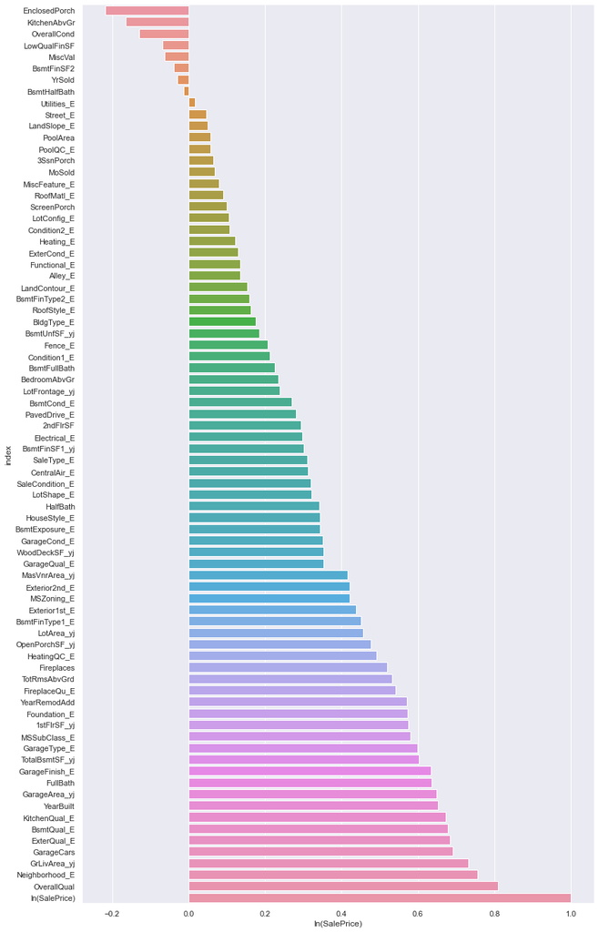

```python
sns.set(rc={'figure.figsize':(13,0.3*SalePrice_corr.shape[0])})
sns.barplot(data=SalePrice_corr, y='index', x='ln(SalePrice)', orient='h')
```

Interestingly, variables like YrSold, OverallCond, MiscVal, etc have a negative corrletion to ln(SalePrice).

# 6. Feature Selection and Retraining

## Mutual Information Score

```python
from sklearn.feature_selection import mutual_info_regression

X_train_transformed = train_transformed.drop('ln(SalePrice)', axis=1)
Y_train_transformed = train_transformed['ln(SalePrice)']

X_test_transformed = test_transformed.copy()


discrete_var = [pd.api.types.is_integer_dtype(t) for t in X_train_transformed.dtypes]

mi = mutual_info_regression(X_train_transformed, Y_train_transformed, discrete_features=discrete_var)
```

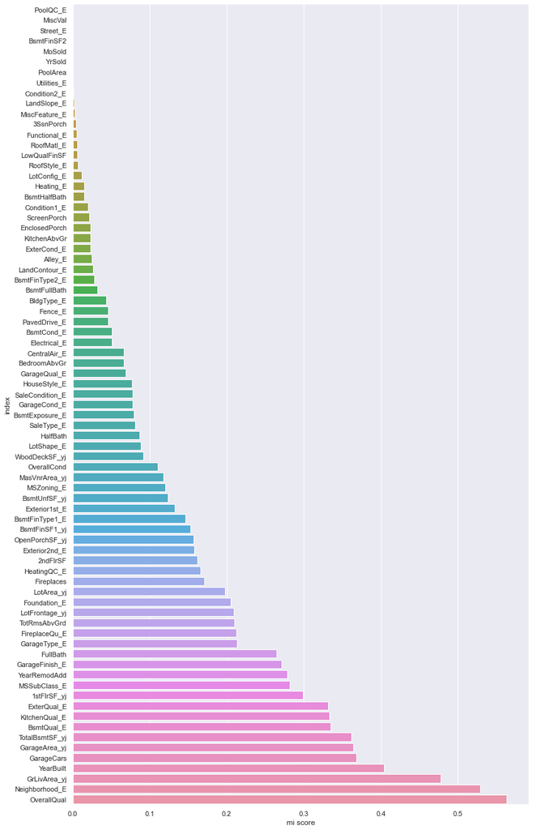

```python
mi_scores = pd.DataFrame([X_train_transformed.columns, mi], index=['index', 'mi score']).T.sort_values(by='mi score')
sns.barplot(data=mi_scores, y='index', x='mi score')
```

```python
mi_scores.loc[mi_scores['mi score']==0, 'index']
```

```
38      PoolQC_E
63       MiscVal
2       Street_E
47    BsmtFinSF2
64        MoSold
65        YrSold
Name: index, dtype: object
```

```python
train_transformed.drop(mi_scores.loc[mi_scores['mi score']==0, 'index'].tolist(), axis=1, inplace=True)
X_train_transformed.drop(mi_scores.loc[mi_scores['mi score']==0, 'index'].tolist(), axis=1, inplace=True)

test_transformed.drop(mi_scores.loc[mi_scores['mi score']==0, 'index'].tolist(), axis=1, inplace=True)
X_test_transformed.drop(mi_scores.loc[mi_scores['mi score']==0, 'index'].tolist(), axis=1, inplace=True)
```

```python
linear_reg = linear_model.LinearRegression()

scores = cross_val_score(linear_reg, X_train_transformed, Y_train_transformed, cv=5, scoring=exp_rmsle)
print("Linear regression with all vars and log(Y): %0.4f RMSLE score after taking exponential of log(Y), with a standard deviation of %0.4f" % (scores.mean(), scores.std()))
```

```
Linear regression with all vars and log(Y): -0.1300 RMSLE score after taking exponential of log(Y), with a standard deviation of 0.0142
```

```python
lasso_reg = linear_model.LassoLarsCV(max_iter=1000)

scores = cross_val_score(lasso_reg, X_train_transformed, Y_train_transformed, cv=5, scoring=exp_rmsle)
print("Linear regression with all vars and log(Y): %0.4f RMSLE score after taking exponential of log(Y), with a standard deviation of %0.4f" % (scores.mean(), scores.std()))
```

```
Linear regression with all vars and log(Y): -0.1285 RMSLE score after taking exponential of log(Y), with a standard deviation of 0.0121
```

```python
lasso_reg.fit(X_train_transformed, Y_train_transformed)
results = lasso_reg.predict(X_test_transformed)
results = np.exp(results)

submission = pd.DataFrame({'Id': test['Id'], 'SalePrice': results})
submission.to_csv('lasso_ordinal_submission.csv', index=False)
```

### Feature Agglomeration

```python
from sklearn.cluster import FeatureAgglomeration


from sklearn import preprocessing
scaler = preprocessing.StandardScaler().fit(X_train_transformed)
X_train_transformed_scaled = scaler.transform(X_train_transformed)


lasso_reg = linear_model.LassoLarsCV(max_iter=1000)
best_rmsle = -1
best_cluster = 0

for i in range(30, X_train_transformed.shape[1], 2):

    agglo = FeatureAgglomeration(n_clusters=i)
    agglo.fit(X_train_transformed_scaled)
    X_train_transformed_scaled_agglo = agglo.transform(X_train_transformed_scaled)

    scores = cross_val_score(lasso_reg, X_train_transformed_scaled_agglo, Y_train_transformed, cv=5, scoring=exp_rmsle)

    if scores.mean() > best_rmsle:
        best_rmsle = scores.mean()
        best_cluster = i
    print('For cluster=', i, ". Lasso RMSLE: %0.4f RMSLE score with a SD of %0.4f" % (scores.mean(), scores.std()))

print('best no of clusters: ', best_cluster)
```

```
For cluster= 30 . Lasso RMSLE: -0.1502 RMSLE score with a SD of 0.0111

For cluster= 32 . Lasso RMSLE: -0.1491 RMSLE score with a SD of 0.0115

For cluster= 34 . Lasso RMSLE: -0.1449 RMSLE score with a SD of 0.0120

For cluster= 36 . Lasso RMSLE: -0.1429 RMSLE score with a SD of 0.0127

For cluster= 38 . Lasso RMSLE: -0.1429 RMSLE score with a SD of 0.0127

For cluster= 40 . Lasso RMSLE: -0.1388 RMSLE score with a SD of 0.0166

For cluster= 42 . Lasso RMSLE: -0.1387 RMSLE score with a SD of 0.0166

For cluster= 44 . Lasso RMSLE: -0.1387 RMSLE score with a SD of 0.0169

For cluster= 46 . Lasso RMSLE: -0.1376 RMSLE score with a SD of 0.0169

For cluster= 48 . Lasso RMSLE: -0.1368 RMSLE score with a SD of 0.0167

For cluster= 50 . Lasso RMSLE: -0.1372 RMSLE score with a SD of 0.0154

For cluster= 52 . Lasso RMSLE: -0.1370 RMSLE score with a SD of 0.0156

For cluster= 54 . Lasso RMSLE: -0.1368 RMSLE score with a SD of 0.0156

For cluster= 56 . Lasso RMSLE: -0.1351 RMSLE score with a SD of 0.0160

For cluster= 58 . Lasso RMSLE: -0.1323 RMSLE score with a SD of 0.0140

For cluster= 60 . Lasso RMSLE: -0.1327 RMSLE score with a SD of 0.0141

For cluster= 62 . Lasso RMSLE: -0.1328 RMSLE score with a SD of 0.0141

For cluster= 64 . Lasso RMSLE: -0.1301 RMSLE score with a SD of 0.0142

For cluster= 66 . Lasso RMSLE: -0.1289 RMSLE score with a SD of 0.0139

For cluster= 68 . Lasso RMSLE: -0.1285 RMSLE score with a SD of 0.0124

For cluster= 70 . Lasso RMSLE: -0.1286 RMSLE score with a SD of 0.0123

best no of clusters:  68
```

### PCA

```python
from sklearn.decomposition import PCA
pca = PCA(n_components='mle').fit(X_train_transformed_scaled)
# print(pca.explained_variance_ratio_)
X_train_transformed_scaled_pca = pca.transform(X_train_transformed_scaled)


lasso_reg = linear_model.LassoLarsCV(max_iter=1000)

scores = cross_val_score(lasso_reg, X_train_transformed_scaled_pca, Y_train_transformed, cv=5, scoring='explained_variance')
print("\nLasso regression after scaling & PCA: %0.2f explained var score with a standard deviation of %0.2f" % (scores.mean(), scores.std()))

scores = cross_val_score(lasso_reg, X_train_transformed_scaled_pca, Y_train_transformed, cv=5, scoring=exp_rmsle)
print("Lasso regression after scaling & PCA: %0.4f RMSLE score after taking exponential of log(Y), with a standard deviation of %0.4f" % (scores.mean(), scores.std()))
```

```
Lasso regression after scaling & PCA: 0.89 explained var score with a standard deviation of 0.02

Lasso regression after scaling & PCA: -0.1296 RMSLE score after taking exponential of log(Y), with a standard deviation of 0.0139
```

### Recursive Feature Elimination

```
Optimal number of features : 66
```

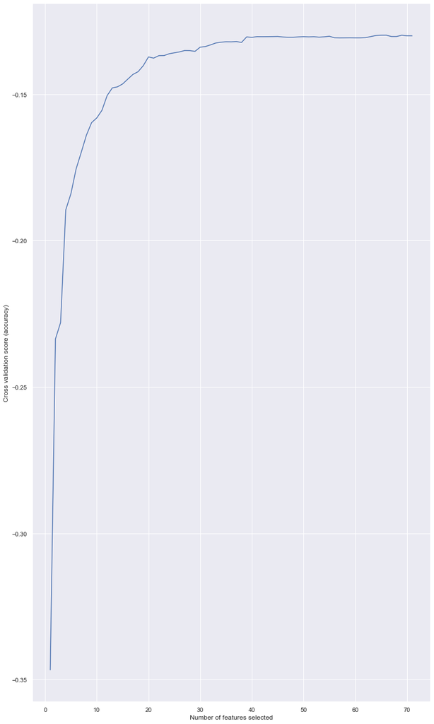

```python
import matplotlib.pyplot as plt
from sklearn.feature_selection import RFECV

min_features_to_select = 1  # Minimum number of features to consider
rfecv = RFECV(
    estimator=linear_reg,
    step=1,
    cv=5,
    scoring=exp_rmsle
)
rfecv.fit(X_train_transformed, Y_train_transformed)

print("Optimal number of features : %d" % rfecv.n_features_)

# Plot number of features VS. cross-validation scores
plt.figure()
plt.xlabel("Number of features selected")
plt.ylabel("Cross validation score (accuracy)")
plt.plot(
    range(min_features_to_select, len(rfecv.grid_scores_) + min_features_to_select),
    rfecv.grid_scores_,
)
plt.show()
```

```python
to_drop = X_train_transformed.columns[rfecv.ranking_ >1].tolist()
to_drop
```

```
['Fence_E', '2ndFlrSF', 'LowQualFinSF', '3SsnPorch', 'PoolArea']
```

```python
lasso_reg = linear_model.LassoLarsCV(max_iter=1000)

X_train_transformed_RFE = X_train_transformed.drop(to_drop, axis=1)
X_test_transformed_RFE = X_test_transformed.drop(to_drop, axis=1)

scores = cross_val_score(lasso_reg, X_train_transformed_RFE, Y_train_transformed, cv=5, scoring=exp_rmsle)
print("Lasso regression with all vars and log(Y): %0.4f RMSLE score after taking exponential of log(Y), with a standard deviation of %0.4f" % (scores.mean(), scores.std()))
```

[output not shown]

With trivial RMSLE score increase, we will adopt RFE

```python
lasso_reg.fit(X_train_transformed_RFE, Y_train_transformed)
lasso_result = np.exp(lasso_reg.predict(X_test_transformed_RFE))

lasso_result = pd.DataFrame([test['Id'], lasso_result], index=['Id', 'SalePrice']).T
lasso_result['Id'] = lasso_result['Id'].astype(int)

lasso_result.to_csv('lasso ordinal rfe submission.csv', index=False)
```

```python
X_train_transformed_RFE
```

|  | MSSubClass_E | MSZoning_E | Alley_E | LotShape_E | LandContour_E | Utilities_E | LotConfig_E | LandSlope_E | Neighborhood_E | Condition1_E | ... | LotArea_yj | MasVnrArea_yj | BsmtFinSF1_yj | BsmtUnfSF_yj | TotalBsmtSF_yj | 1stFlrSF_yj | GrLivArea_yj | GarageArea_yj | WoodDeckSF_yj | OpenPorchSF_yj |
| --- | --- | --- | --- | --- | --- | --- | --- | --- | --- | --- | --- | --- | --- | --- | --- | --- | --- | --- | --- | --- | --- |
| 0 | 15 | 4 | 2 | 1 | 2 | 2 | 1 | 1 | 17 | 4 | ... | -0.141171 | 1.230708 | 0.797537 | -0.887576 | -0.404029 | -0.799624 | 0.528531 | 0.383899 | -0.950337 | 0.841820 |
| 1 | 11 | 4 | 2 | 1 | 2 | 2 | 3 | 1 | 20 | 2 | ... | 0.105609 | -0.818452 | 1.011471 | -0.434388 | 0.508177 | 0.429151 | -0.382755 | -0.004602 | 1.213714 | -1.071307 |
| 2 | 15 | 4 | 2 | 2 | 2 | 2 | 1 | 1 | 17 | 4 | ... | 0.413721 | 1.193873 | 0.571325 | -0.048083 | -0.253787 | -0.568533 | 0.659112 | 0.641990 | -0.950337 | 0.668453 |
| 3 | 10 | 4 | 2 | 2 | 2 | 2 | 2 | 1 | 19 | 4 | ... | 0.095490 | -0.818452 | 0.142272 | 0.183337 | -0.644806 | -0.429428 | 0.540797 | 0.786092 | -0.950337 | 0.584540 |
| 4 | 15 | 4 | 2 | 2 | 2 | 2 | 3 | 1 | 24 | 4 | ... | 0.877127 | 1.333038 | 0.750541 | 0.077485 | 0.254387 | 0.124698 | 1.282894 | 1.583257 | 1.079695 | 0.991895 |
| ... | ... | ... | ... | ... | ... | ... | ... | ... | ... | ... | ... | ... | ... | ... | ... | ... | ... | ... | ... | ... | ... |
| 1455 | 15 | 4 | 2 | 1 | 2 | 2 | 1 | 1 | 14 | 4 | ... | -0.266808 | -0.818452 | -1.353159 | 0.909505 | -0.177387 | -0.456061 | 0.415837 | -0.004602 | -0.950337 | 0.645943 |
| 1456 | 11 | 4 | 2 | 1 | 2 | 2 | 1 | 1 | 15 | 4 | ... | 0.722071 | 1.130602 | 0.869532 | 0.282161 | 1.092127 | 1.946238 | 1.106859 | 0.173581 | 1.260813 | -1.071307 |
| 1457 | 10 | 4 | 2 | 1 | 2 | 2 | 1 | 1 | 19 | 4 | ... | -0.010330 | -0.818452 | 0.261742 | 0.790731 | 0.269755 | 0.240338 | 1.471180 | -0.987927 | -0.950337 | 0.834100 |
| 1458 | 11 | 4 | 2 | 1 | 2 | 2 | 1 | 1 | 10 | 4 | ... | 0.129088 | -0.818452 | -0.460226 | -2.064084 | 0.106028 | -0.065163 | -0.854788 | -1.048544 | 1.274883 | -1.071307 |
| 1459 | 11 | 4 | 2 | 1 | 2 | 2 | 1 | 1 | 5 | 4 | ... | 0.172505 | -0.818452 | 0.901757 | -0.945776 | 0.495315 | 0.414293 | -0.397037 | -0.868284 | 1.475782 | 0.892639 |

1460 rows × 66 columns

### K-Means Clustering (not an improvement)

```python
from sklearn.cluster import KMeans

kmeans = KMeans(n_clusters=2, n_init=1, init="random")
kmeans.fit(X_train_transformed_RFE)

train_labels = kmeans.labels_
test_labels = kmeans.predict(X_test_transformed_RFE)
```

```python
_ = pd.DataFrame([Y_train_transformed, kmeans.labels_], index=['ln(SalePrice)', 'label']).T
```

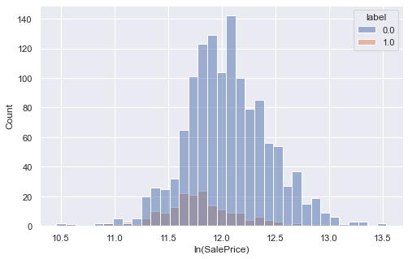

```python
sns.set(rc={'figure.figsize':(8,5)})
sns.histplot(data=_, x='ln(SalePrice)', hue='label')
```

```python
X_train_transformed_RFE_0 = X_train_transformed_RFE[kmeans.labels_==0]
X_train_transformed_RFE_1 = X_train_transformed_RFE[kmeans.labels_==1]

Y_train_transformed_0 = Y_train_transformed[kmeans.labels_==0]
Y_train_transformed_1 = Y_train_transformed[kmeans.labels_==1]

X_test_transformed_RFE_0 = X_test_transformed_RFE[test_labels==0]
X_test_transformed_RFE_1 = X_test_transformed_RFE[test_labels==1]
```

```python
lasso_reg = linear_model.LassoLarsCV(max_iter=80)

scores = cross_val_score(lasso_reg, X_train_transformed_RFE_0, Y_train_transformed_0, cv=5, scoring=exp_rmsle)
print("Lasso regression group 0 with k means: %0.4f RMSLE score after taking exponential of log(Y), with a standard deviation of %0.4f" % (scores.mean(), scores.std()))
```

```
Lasso regression group 0 with k means: -0.1074 RMSLE score after taking exponential of log(Y), with a standard deviation of 0.0081
```

```python
lasso_reg = linear_model.LassoLarsCV(max_iter=1000)

scores = cross_val_score(lasso_reg, X_train_transformed_RFE_1, Y_train_transformed_1, cv=5, scoring=exp_rmsle)
print("Lasso regression group 0 with k means: %0.4f RMSLE score after taking exponential of log(Y), with a standard deviation of %0.4f" % (scores.mean(), scores.std()))
```

```
Lasso regression group 0 with k means: -0.1292 RMSLE score after taking exponential of log(Y), with a standard deviation of 0.0127
```

```python
lasso_reg = LassoLarsCV()
lasso_reg.fit(X_train_transformed_RFE_0, Y_train_transformed_0)
result_g0 = np.exp(lasso_reg.predict(X_test_transformed_RFE_0))


lasso_reg = LassoLarsCV()
lasso_reg.fit(X_train_transformed_RFE_1, Y_train_transformed_1)
result_g1 = np.exp(lasso_reg.predict(X_test_transformed_RFE_1))
```

```python
#need to change the ID series to list first, otherwise when creating the DF, pandas will combine the arrays depending on the existing index
result_g0 = pd.DataFrame([test.loc[test_labels==0, 'Id'].tolist(), result_g0], index=['Id', 'SalePrice']).T
result_g1 = pd.DataFrame([test.loc[test_labels==1, 'Id'].tolist(), result_g1], index=['Id', 'SalePrice']).T
```

```python
seg_regression_submission = pd.concat([result_g0, result_g1], ignore_index=True)
seg_regression_submission['Id'] = seg_regression_submission['Id'].astype(int)
```

```python
seg_regression_submission.to_csv('seg_regression.csv', index=False)
```